# Lab 2 - Style Transfer

*Michael Han, Vince Miller, Ryan Cole*

In this lab you will implement a photo realistic style transfer algorithm, using the work of Li et al. in their universal style transfer paper. An implementation of training a decoder for different scales of VGG has already been implemented for you (https://github.com/8000net/universal-style-transfer-keras (Links to an external site.)Links to an external site.). For photo realistic transfer, you will be implementing the smoothing constraint from Li et al. discussed in lecture, as well as adding un-pooling layers to the implementation.

**[10 Points]** Manipulate the above VGG code to use un-pooling layers as in the Photo Realistic Li et al. paper. Alternatively, you can use another implementation (perhaps not using Keras) if you like.

We used the code from SegNet to create pooling and unpooling layers with indices.

```python
import sys
import os

# copy sample_user_settings.yaml to user_settings.yaml and change as desired
import yaml
with open('user_settings.yaml') as fp:
    user_settings = yaml.load(fp)
user_settings['coco_path']
```

```
'D:\\Michael\\Downloads\\train2017'
```

```python
from keras import backend as K
from keras.models import Model, load_model
from keras.layers import Conv2D, MaxPooling2D, GlobalMaxPooling2D, Input, Layer, Lambda, UpSampling2D
from keras.utils.data_utils import get_file
from keras import backend as K
import h5py
import numpy as np
import tensorflow as tf
import math
from keras.preprocessing.image import ImageDataGenerator
from keras.preprocessing import image

# train.py contains code from the train section of (https://github.com/8000net/universal-style-transfer-keras)
import train as tr
from model import EncoderDecoder
from util import count_num_samples
from PIL import Image
from scipy.misc import imresize, imsave

from scipy.misc import imsave

from vgg import VGG19, preprocess_input
```

```python
# max pooling and unpooling from https://github.com/ykamikawa/tf-keras-SegNet/blob/master/layers.py

# create Max Pooling layer and return argmax indices
class MaxPoolingWithArgmax2D(Layer):
    # initialize with appropriate settings
    def __init__(
            self,
            pool_size=(2, 2),
            strides=(2, 2),
            padding='same',
            **kwargs):
        super(MaxPoolingWithArgmax2D, self).__init__(**kwargs)
        self.padding = padding
        self.pool_size = pool_size
        self.strides = strides

    # custom layers usually include a build() function which is not necessary here because the layer has no weights

    # peform max pooling
    def call(self, inputs, **kwargs):
        padding = self.padding
        pool_size = self.pool_size
        strides = self.strides
        if K.backend() == 'tensorflow':
            ksize = [1, pool_size[0], pool_size[1], 1]
            padding = padding.upper()
            strides = [1, strides[0], strides[1], 1]
            # max_pool_with_argmax returns two tensors, one with input pooled and another with masking indices
            output, argmax = K.tf.nn.max_pool_with_argmax(
                    inputs,
                    ksize=ksize,
                    strides=strides,
                    padding=padding)
        else:
            errmsg = '{} backend is not supported for layer {}'.format(
                    K.backend(), type(self).__name__)
            raise NotImplementedError(errmsg)

        # cast to default keras floating point type
        argmax = K.cast(argmax, K.floatx())
        return [output, argmax]

    # required function for custom Keras layer
    def compute_output_shape(self, input_shape):
        ratio = (1, 2, 2, 1)
        output_shape = [
                dim//ratio[idx]
                if dim is not None else None
                for idx, dim in enumerate(input_shape)]
        output_shape = tuple(output_shape)
        return [output_shape, output_shape]

    # masking functionality exists in Keras and would be implemented here if this custom layer supported it
    def compute_mask(self, inputs, mask=None):
        return 2 * [None]


# unpool the MaxPooling layer but retain location of original max values
class MaxUnpooling2D(Layer):
    def __init__(self, size=(2, 2), **kwargs):
        super(MaxUnpooling2D, self).__init__(**kwargs)
        self.size = size

    # perform max unpooling
    def call(self, inputs, output_shape=None):
        # separate input list
        updates, mask = inputs[0], inputs[1]
        with K.tf.variable_scope(self.name):
            # recast mask to int (from boolean)
            mask = K.cast(mask, 'int32')
            # get shape of tensor
            input_shape = K.tf.shape(updates, out_type='int32')
            #  calculation new shape
            if output_shape is None:
                # 2x2 unpooling
                output_shape = (
                        input_shape[0],
                        input_shape[1]*self.size[0],  # repeat rows
                        input_shape[2]*self.size[1],  # repeat cols
                        input_shape[3])
            self.output_shape1 = output_shape

            # calculation indices for batch, height, width and feature maps
            # creates ones in same shape as mask tensor
            one_like_mask = K.ones_like(mask, dtype='int32')
            # stack vertically
            batch_shape = K.concatenate(
                    [[input_shape[0]], [1], [1], [1]],
                    axis=0)
            # count batches
            batch_range = K.reshape(
                    K.tf.range(output_shape[0], dtype='int32'),
                    shape=batch_shape)
            b = one_like_mask * batch_range
            y = mask // (output_shape[2] * output_shape[3])
            x = (mask // output_shape[3]) % output_shape[2]
            feature_range = K.tf.range(output_shape[3], dtype='int32')
            f = one_like_mask * feature_range

            # transpose indices & reshape update values to one dimension
            updates_size = K.tf.size(updates)
            indices = K.transpose(K.reshape(
                K.stack([b, y, x, f]),
                [4, updates_size]))
            values = K.reshape(updates, [updates_size])
            ret = K.tf.scatter_nd(indices, values, output_shape)
            return ret

    def compute_output_shape(self, input_shape):
        mask_shape = input_shape[1]
        return (
                mask_shape[0],
                mask_shape[1]*self.size[0],
                mask_shape[2]*self.size[1],
                mask_shape[3]
                )
```

We build and train full models with both the encoder and decoder, and create disconnected encoder and decoder models later in this notebook.

```python
# model_1 is 2-block and model_2 is 5-block

def model_1():

    inputs = Input(shape=(256, 256, 3))

    #####encoder is first 6

    # Block 1
    x = Conv2D(64, (3, 3), activation='relu', padding='same', name='block1_conv1')(inputs)
    x = Conv2D(64, (3, 3), activation='relu', padding='same', name='block1_conv2')(x)
    x, mask_1 = MaxPoolingWithArgmax2D((2,2))(x)

    # Block 2
    x = Conv2D(128, (3, 3), activation='relu', padding='same', name='block2_conv1')(x)
    x = Conv2D(128, (3, 3), activation='relu', padding='same', name='block2_conv2')(x)
    x, mask_2 = MaxPoolingWithArgmax2D((2,2))(x)

    #####decoder is last 6

    x = MaxUnpooling2D((2,2))([x, mask_2])
    x = Conv2D(128, (3, 3), activation='relu', padding='same', name='decoder_block2_conv2')(x)
    x = Conv2D(64, (3, 3), activation='relu', padding='same', name='decoder_block2_conv1')(x)

    x = MaxUnpooling2D((2,2))([x, mask_1])
    x = Conv2D(64, (3, 3), activation='relu', padding='same', name='decoder_block1_conv2')(x)
    output = Conv2D(3, (3, 3), activation='relu', padding='same',name='decoder_out')(x)

    return Model(inputs, output, name='two_layer_model')

# 5-block model
def model_2():

    inputs = Input(shape=(256, 256, 3))

    #####encoder is first 14 layers

    # Block 1
    x = Conv2D(64, (3, 3), activation='relu', padding='same', name='block1_conv1')(inputs)
    x = Conv2D(64, (3, 3), activation='relu', padding='same', name='block1_conv2')(x)
    x, mask_1 = MaxPoolingWithArgmax2D((2,2))(x)

    # Block 2
    x = Conv2D(128, (3, 3), activation='relu', padding='same', name='block2_conv1')(x)
    x = Conv2D(128, (3, 3), activation='relu', padding='same', name='block2_conv2')(x)
    x, mask_2 = MaxPoolingWithArgmax2D((2,2))(x)

    # Block 3
    x = Conv2D(256, (3, 3), activation='relu', padding='same', name='block3_conv1')(x)
    x = Conv2D(256, (3, 3), activation='relu', padding='same', name='block3_conv2')(x)
    x = Conv2D(256, (3, 3), activation='relu', padding='same', name='block3_conv3')(x)
    x, mask_3 = MaxPoolingWithArgmax2D((2,2))(x)

    # Block 4
    x = Conv2D(512, (3, 3), activation='relu', padding='same', name='block4_conv1')(x)
    x = Conv2D(512, (3, 3), activation='relu', padding='same', name='block4_conv2')(x)
    x = Conv2D(512, (3, 3), activation='relu', padding='same', name='block4_conv3')(x)
    x, mask_4 = MaxPoolingWithArgmax2D((2,2))(x)

    #####decoder is last 14

    x = MaxUnpooling2D((2,2))([x, mask_4])
    x = Conv2D(512, (3, 3), activation='relu', padding='same', name='decoder_block4_conv3')(x)
    x = Conv2D(512, (3, 3), activation='relu', padding='same', name='decoder_block4_conv2')(x)
    x = Conv2D(256, (3, 3), activation='relu', padding='same', name='decoder_block4_conv1')(x)

    x = MaxUnpooling2D((2,2))([x, mask_3])
    x = Conv2D(256, (3, 3), activation='relu', padding='same', name='decoder_block3_conv3')(x)
    x = Conv2D(256, (3, 3), activation='relu', padding='same', name='decoder_block3_conv2')(x)
    x = Conv2D(128, (3, 3), activation='relu', padding='same', name='decoder_block3_conv1')(x)

    x = MaxUnpooling2D((2,2))([x, mask_2])
    x = Conv2D(128, (3, 3), activation='relu', padding='same', name='decoder_block2_conv2')(x)
    x = Conv2D(64, (3, 3), activation='relu', padding='same', name='decoder_block2_conv1')(x)

    x = MaxUnpooling2D((2,2))([x, mask_1])
    x = Conv2D(64, (3, 3), activation='relu', padding='same', name='decoder_block1_conv2')(x)
    output = Conv2D(3, (3, 3), activation='relu', padding='same',name='decoder_out')(x)

    return Model(inputs, output, name='five_layer_model')
```

```python
LAMBDA = 1

## Loss functions taken from model.py

def l2_loss(x):
    return K.sum(K.square(x)) / 2

# creates the loss function for the encodings comparing the input image with the output image and minimizing the loss between
def create_loss_fn(encoder, target_layer):
        def get_encodings(inputs):
            encoder = VGG19(inputs, input_shape=(256, 256, 3), target_layer = target_layer)
            return encoder.output

        def loss(img_in, img_out):
            encoding_in = get_encodings(img_in)
            encoding_out = get_encodings(img_out)
            return l2_loss(img_out - img_in) + \
                   LAMBDA*l2_loss(encoding_out - encoding_in)
        return loss
```

### Training our EncoderDecoder model

**[10 Points]** Train two image decoders that can decode an image from two different convolutional outputs from VGG using un-pooling. If using Keras, there is starter code available at the link above. You may use any image dataset you like. Alternatively, you may use pre-trained decoder weights (from anywhere online). Be sure to cite any code or weights you use properly.

#### Model 1

```python
import train as tr
from vgg import VGG19, preprocess_input

from util import count_num_samples
from keras.preprocessing.image import ImageDataGenerator

TRAIN_PATH = user_settings['coco_path']
TARGET_SIZE = (256, 256)
BATCH_SIZE = 3
epochs = 2
target_layer = 2

gen = tr.create_gen(TRAIN_PATH, TARGET_SIZE, BATCH_SIZE)

num_samples = count_num_samples(TRAIN_PATH)
steps_per_epoch = num_samples // BATCH_SIZE

encoder = VGG19(input_shape=(256, 256, 3), target_layer = target_layer)
loss = create_loss_fn(encoder = encoder, target_layer = target_layer)

encoder_decoder = model_1() ###### Using two layer model
encoder_decoder.compile('adam', loss = loss)

callbacks = [tr.OutputPreview(encoder_decoder, './monkey.jpg', 5000, './preview-%d' % target_layer)]
```

```
Found 118287 images belonging to 1 classes.
```

```python
# train full model with encoder and decoder together
retrain = False
if retrain:
    encoder_decoder.fit_generator(gen, steps_per_epoch=steps_per_epoch,
             epochs=epochs, callbacks=callbacks)
    encoder_decoder.save('model_at_%s.h5' % target_layer)
```

#### Model 2

```python
from vgg import VGG19, preprocess_input


TRAIN_PATH = user_settings['coco_path']
TARGET_SIZE = (256, 256)
BATCH_SIZE = 3
epochs = 2
target_layer = 5

gen = tr.create_gen(TRAIN_PATH, TARGET_SIZE, BATCH_SIZE)

num_samples = count_num_samples(TRAIN_PATH)
steps_per_epoch = num_samples // BATCH_SIZE

encoder = VGG19(input_shape=(256, 256, 3), target_layer = target_layer)
loss = create_loss_fn(encoder = encoder, target_layer = target_layer)

encoder_decoder = model_2() ###### Using two layer model
encoder_decoder.compile('adam', loss = loss)

callbacks = [tr.OutputPreview(encoder_decoder, './monkey.jpg', 5000, './preview-%d' % target_layer)]
```

```
Found 118287 images belonging to 1 classes.
```

```python
# train full model with encoder and decoder together
retrain = False
if retrain:
    encoder_decoder.fit_generator(gen, steps_per_epoch=steps_per_epoch,
         epochs=epochs, callbacks=callbacks)
    encoder_decoder.save('model_at_%s.h5' % target_layer)
```

### Reconstruction

**[10 Points]** Show a few images and their reconstructions using each decoder. Comment on any artifacts from the images.]

Below we reconstruct several images using the full model, which includes the decoder (we split the full model into encoder and decoder segments later in this notebook).

```python
import matplotlib.pyplot as plt
import cv2
from PIL import Image


def img_recon(model,img_path):
    img = Image.open(img_path)
    img = np.asarray(img)

    # resize image for model prediction
    img=cv2.resize(img,(256,256))
    # expand dimensions for batch
    img = np.expand_dims(img, axis=0)
    recon=model.predict(img)

    # remove batch dimension
    recon=np.squeeze(recon)
    # clips pixel value to 0-255
    recon=recon.astype(int)
    recon=np.clip(recon, 0, 255)
    return recon
```

```python
mod1=model_1()
mod1.load_weights('./models/model1.h5')

mod2=model_2()
mod2.load_weights('./models/model2.h5')

def show_result(image_path):
    img = Image.open(image_path)
    img = np.asarray(img)
    plt.figure(figsize=(4,6))
    plt.imshow(img)
    plt.title('Original img')

    plt.figure(figsize=(8,8))
    plt.subplot(1,2,1)
    recon=img_recon(mod1,image_path)
    plt.imshow( recon )
    plt.title('Model 1 with 2 Layers')

    plt.subplot(1,2,2)
    recon=img_recon(mod2,image_path)
    plt.imshow(recon)
    plt.title('Model 2 with 5 Layers')
```

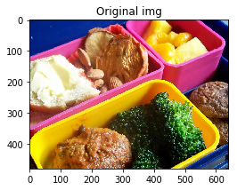

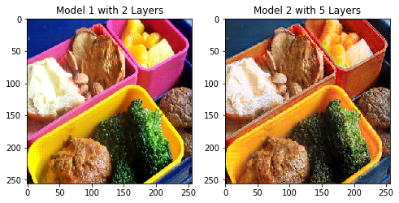

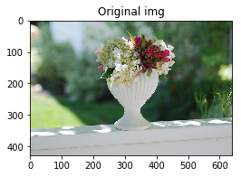

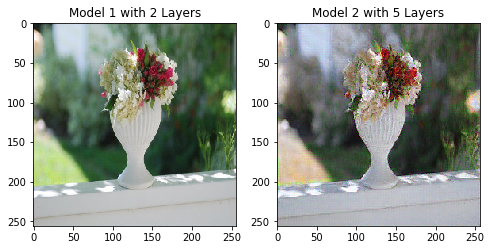

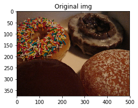

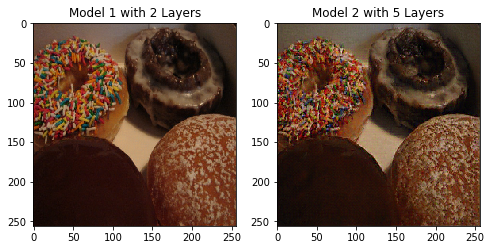

```python
img_path=r'D:\Michael\Downloads\train2017\train2017\000000000009.jpg'
show_result(img_path)

img_path=r'D:\Michael\Downloads\train2017\train2017\000000000030.jpg'
show_result(img_path)

img_path=r'D:\Michael\Downloads\train2017\train2017\000000581913.jpg'
show_result(img_path)
```

We note that the 5-layer mddel has a more detailed texture, and a dimmer color palette compared to the 2-layer network.

## Whitening and Coloring

**[10 Points]** Exceptional work: Implement the smoothing constraint from Li et al. to achieve photo realistic style transfer results. Show a few photo style changes from the network. If using code from another author (not your own), you will be graded on the clarity of explanatory comments you add to the code.

We referred to code by Michael Shu and Niraj when creating the following encoder_decoder_structure functions.

The decoder model has two input layers and the encoder half of the network structure is not connected to the decoder half, but the decoder is dependent on the masks produced in the encoder section.

```python
# create encoder architecture with one input, or decoder with two
# inspired by Michael Shu and Niraj to create decoder structure
# decoder has two input layers and the final MaxPooling layer is a deadend.
def encoder_decoder_structure_1(encoder_inputs, decoder_inputs=None):

    # Block 1
    x = Conv2D(64, (3, 3), activation='relu', padding='same', name='block1_conv1')(encoder_inputs)
    x = Conv2D(64, (3, 3), activation='relu', padding='same', name='block1_conv2')(x)
    x, mask_1 = MaxPoolingWithArgmax2D((2,2))(x)


    # Block 2
    x = Conv2D(128, (3, 3), activation='relu', padding='same', name='block2_conv1')(x)
    x = Conv2D(128, (3, 3), activation='relu', padding='same', name='block2_conv2')(x)
    encoder_output, mask_2 = MaxPoolingWithArgmax2D((2,2))(x)

    if decoder_inputs is None:
        return encoder_output

    x = MaxUnpooling2D((2,2))([decoder_inputs, mask_2])
    x = Conv2D(128, (3, 3), activation='relu', padding='same', name='decoder_block2_conv2')(x)
    x = Conv2D(64, (3, 3), activation='relu', padding='same', name='decoder_block2_conv1')(x)

    x = MaxUnpooling2D((2,2))([x, mask_1])
    x = Conv2D(64, (3, 3), activation='relu', padding='same', name='decoder_block1_conv2')(x)
    decoder_output = Conv2D(3, (3, 3), activation='relu', padding='same',name='decoder_out')(x)
    return decoder_output
```

```python
# create encoder architecture with one input, or decoder with two
# inspired by Shu et al to recreate structure without creating network model to avoid passing masks around
def encoder_decoder_structure_2(encoder_inputs, decoder_inputs=None):
    #####encoder is first 14 layers

    # Block 1
    x = Conv2D(64, (3, 3), activation='relu', padding='same', name='block1_conv1')(encoder_inputs)
    x = Conv2D(64, (3, 3), activation='relu', padding='same', name='block1_conv2')(x)
    x, mask_1 = MaxPoolingWithArgmax2D((2,2))(x)

    # Block 2
    x = Conv2D(128, (3, 3), activation='relu', padding='same', name='block2_conv1')(x)
    x = Conv2D(128, (3, 3), activation='relu', padding='same', name='block2_conv2')(x)
    x, mask_2 = MaxPoolingWithArgmax2D((2,2))(x)

    # Block 3
    x = Conv2D(256, (3, 3), activation='relu', padding='same', name='block3_conv1')(x)
    x = Conv2D(256, (3, 3), activation='relu', padding='same', name='block3_conv2')(x)
    x = Conv2D(256, (3, 3), activation='relu', padding='same', name='block3_conv3')(x)
    x, mask_3 = MaxPoolingWithArgmax2D((2,2))(x)

    # Block 4
    x = Conv2D(512, (3, 3), activation='relu', padding='same', name='block4_conv1')(x)
    x = Conv2D(512, (3, 3), activation='relu', padding='same', name='block4_conv2')(x)
    x = Conv2D(512, (3, 3), activation='relu', padding='same', name='block4_conv3')(x)
    encoder_output, mask_4 = MaxPoolingWithArgmax2D((2,2))(x)

    if decoder_inputs is None:
        return encoder_output

    #####decoder is last 14

    x = MaxUnpooling2D((2,2))([decoder_inputs, mask_4])
    x = Conv2D(512, (3, 3), activation='relu', padding='same', name='decoder_block4_conv3')(x)
    x = Conv2D(512, (3, 3), activation='relu', padding='same', name='decoder_block4_conv2')(x)
    x = Conv2D(256, (3, 3), activation='relu', padding='same', name='decoder_block4_conv1')(x)

    x = MaxUnpooling2D((2,2))([x, mask_3])
    x = Conv2D(256, (3, 3), activation='relu', padding='same', name='decoder_block3_conv3')(x)
    x = Conv2D(256, (3, 3), activation='relu', padding='same', name='decoder_block3_conv2')(x)
    x = Conv2D(128, (3, 3), activation='relu', padding='same', name='decoder_block3_conv1')(x)

    x = MaxUnpooling2D((2,2))([x, mask_2])
    x = Conv2D(128, (3, 3), activation='relu', padding='same', name='decoder_block2_conv2')(x)
    x = Conv2D(64, (3, 3), activation='relu', padding='same', name='decoder_block2_conv1')(x)

    x = MaxUnpooling2D((2,2))([x, mask_1])
    x = Conv2D(64, (3, 3), activation='relu', padding='same', name='decoder_block1_conv2')(x)
    decoder_output = Conv2D(3, (3, 3), activation='relu', padding='same',name='decoder_out')(x)

    return decoder_output
```

```python
# performs whitening and coloring transform on content and style image

def wct(content, style, alpha=0.6, eps=1e-15):
    '''
    https://github.com/eridgd/WCT-TF/blob/master/ops.py

    Perform Whiten-Color Transform on feature maps using numpy
    See p.4 of the Universal Style Transfer paper for equations:
    https://arxiv.org/pdf/1705.08086.pdf
    '''

    # 1xHxWxC -> CxHxW
    # here the images dimensions are reduced by 1 and the images is transposed
    content_t = np.transpose(np.squeeze(content), (2, 0, 1))
    style_t = np.transpose(np.squeeze(style), (2, 0, 1))

    # CxHxW -> CxH*W
    # each image is flattened
    content_flat = content_t.reshape(-1, content_t.shape[1]*content_t.shape[2])
    style_flat = style_t.reshape(-1, style_t.shape[1]*style_t.shape[2])

    # Whitening transform
    # the content image has its image structure maintained and an unstyled image gram is found
    mc = content_flat.mean(axis=1, keepdims=True)
    fc = content_flat - mc
    fcfc = np.dot(fc, fc.T) / (content_t.shape[1]*content_t.shape[2] - 1)
    Ec, wc, _ = np.linalg.svd(fcfc)
    k_c = (wc > 1e-5).sum()
    Dc = np.diag((wc[:k_c]+eps)**-0.5)
    fc_hat = Ec[:,:k_c].dot(Dc).dot(Ec[:,:k_c].T).dot(fc)

    # Coloring transform
    # the style image gram is used to transform the whitened gram of the content image that was found above
    ms = style_flat.mean(axis=1, keepdims=True)
    fs = style_flat - ms
    fsfs = np.dot(fs, fs.T) / (style_t.shape[1]*style_t.shape[2] - 1)
    Es, ws, _ = np.linalg.svd(fsfs)
    k_s = (ws > 1e-5).sum()
    Ds = np.sqrt(np.diag(ws[:k_s]+eps))
    fcs_hat = Es[:,:k_s].dot(Ds).dot(Es[:,:k_s].T).dot(fc_hat)
    fcs_hat = fcs_hat + ms

    # Blend transform features with original features
    # adjust amount of orgingal image and transformed image makes up the final image
    blended = alpha*fcs_hat + (1 - alpha)*(fc)

    # CxH*W -> CxHxW
    blended = blended.reshape(content_t.shape)
    # CxHxW -> 1xHxWxC
    blended = np.expand_dims(np.transpose(blended, (1,2,0)), 0)

    return np.float32(blended)
```

```python
# style transfer from one image to another using encoder and decoder
def style_transfer_1(content_file_name = 'monkey.jpg', style_file_name = 'starry_night.jpg', propagator=None):

    # load images
    content_img = image.load_img(content_file_name)
    content_img = image.img_to_array(content_img)
    content_img = imresize(content_img, (256, 256, 3))
    orig_content_img_array = content_img
    content_img_shape = content_img.shape
    content_img = np.expand_dims(content_img, axis=0)

    style_img = image.load_img(style_file_name)
    style_img = image.img_to_array(style_img)
    style_img = imresize(style_img, (256, 256, 3))
    style_img_shape = style_img.shape
    style_img = np.expand_dims(style_img, axis=0)

    # base code for function to create encoder and decoder
    model1_first_decoder_layer = 6 + 1  # + 1 for input layer

    # custom objects dict requires to load models saved with custom layers
    custom_objects={'MaxPoolingWithArgmax2D': MaxPoolingWithArgmax2D,
                    'MaxUnpooling2D': MaxUnpooling2D,
                    'loss': loss
                    }

    # load previous model to access weights
    model1 = load_model('decoder_2.h5', custom_objects=custom_objects)

    # create encoder
    encoder_inputs = Input(shape=(256, 256, 3))
    encoder_structure = encoder_decoder_structure_1(encoder_inputs)
    encoder_model = Model(encoder_inputs, encoder_structure, name='encoder_model_1')

    # load weights trained from full model
    full_model_layers = model1.layers[:model1_first_decoder_layer]
    for i in range(len(encoder_model.layers)):
        encoder_model.layers[i].set_weights(full_model_layers[i].get_weights())

    encoded_content = encoder_model.predict(content_img)
    encoded_style = encoder_model.predict(style_img)

    # apply whitening and coloring transform
    transformed_content_style = wct(encoded_content, encoded_style)
    decoder_inputs = Input(shape = transformed_content_style.shape[1:])
    decoder_structure = encoder_decoder_structure_1(encoder_inputs, decoder_inputs)
    decoder_model = Model([encoder_inputs, decoder_inputs], decoder_structure, name='decoder_model_1')

    # load weights trained from full model
    # hard-coding because Keras inserts the 2nd input layer before the MaxPoolingLayer, even though they are not connected
    full_model_layers = model1.layers
    for i in range(6):
        decoder_model.layers[i].set_weights(full_model_layers[i].get_weights())
    for i in range(7,14):
        decoder_model.layers[i].set_weights(full_model_layers[i-1].get_weights())

    import matplotlib.pyplot as plt

    img = decoder_model.predict([content_img, transformed_content_style])

    plt.imshow(np.clip(img[0] / 255, 0, 1))
    plt.title('stylized image')
    plt.show()

    # draw content and style images after WCT
    plt.figure(figsize=(8,8))
    plt.subplot(1,2,1)
    plt.imshow(image.load_img(content_file_name))
    plt.title('Content Image before WCT')

    plt.subplot(1,2,2)
    plt.imshow(image.load_img(style_file_name))
    plt.title('Style Image before WCT')

    if propagator is not None:
        smooth_img = propagator.process(img[0], orig_content_img_array)
        smooth_img = np.expand_dims(smooth_img, axis=0)
        plt.imshow(np.clip(smooth_img[0] / 255, 0, 1))
        plt.title('Smooth image')
        plt.show()
```

```python
def style_transfer_2(content_file_name = 'monkey.jpg', style_file_name = 'starry_night.jpg', propagator=None):
    from keras.preprocessing import image

    # load images
    content_img = image.load_img(content_file_name)
    content_img = image.img_to_array(content_img)
    content_img = imresize(content_img, (256, 256, 3))
    orig_content_img_array = content_img
    content_img_shape = content_img.shape
    content_img = np.expand_dims(content_img, axis=0)

    style_img = image.load_img(style_file_name)
    style_img = image.img_to_array(style_img)
    style_img = imresize(style_img, (256, 256, 3))
    style_img_shape = style_img.shape
    style_img = np.expand_dims(style_img, axis=0)

    # base code for function to create encoder and decoder
    model2_first_decoder_layer = 14 + 1  # + 1 for input layer

    # custom objects dict requires to load models saved with custom layers
    custom_objects={'MaxPoolingWithArgmax2D': MaxPoolingWithArgmax2D,
                    'MaxUnpooling2D': MaxUnpooling2D,
                    'loss': loss
                    }

    # load previous model to access weights
    model2 = load_model('decoder_5.h5', custom_objects=custom_objects)

    # create encoder
    encoder_inputs = Input(shape=(256, 256, 3))
    encoder_structure = encoder_decoder_structure_2(encoder_inputs)
    encoder_model = Model(encoder_inputs, encoder_structure, name='encoder_model_2')

    # load weights trained from full model
    full_model_layers = model2.layers[:model2_first_decoder_layer]
    for i in range(len(encoder_model.layers)):
        encoder_model.layers[i].set_weights(full_model_layers[i].get_weights())

    encoded_content = encoder_model.predict(content_img)
    encoded_style = encoder_model.predict(style_img)

    # apply whitening and coloring transform
    transformed_content_style = wct(encoded_content, encoded_style)
    decoder_inputs = Input(shape = transformed_content_style.shape[1:])
    decoder_structure = encoder_decoder_structure_2(encoder_inputs, decoder_inputs)
    decoder_model = Model([encoder_inputs, decoder_inputs], decoder_structure, name='decoder_model_2')

    # load weights trained from full model
    # hard-coding because Keras inserts the 2nd input layer before the MaxPoolingLayer, even though they are not connected
    full_model_layers = model2.layers
    for i in range(13):
        decoder_model.layers[i].set_weights(full_model_layers[i].get_weights())
    for i in range(15,30):
        decoder_model.layers[i].set_weights(full_model_layers[i-1].get_weights())

    import matplotlib.pyplot as plt
    img = decoder_model.predict([content_img, transformed_content_style])


    plt.imshow(np.clip(img[0] / 255, 0, 1))
    plt.title('stylized image')
    plt.show()

    # draw content and style images after WCT
    plt.figure(figsize=(8,8))
    plt.subplot(1,2,1)
    plt.imshow(image.load_img(content_file_name))
    plt.title('Content Image before WCT')

    plt.subplot(1,2,2)
    plt.imshow(image.load_img(style_file_name))
    plt.title('Style Image before WCT')

    if propagator is not None:
        smooth_img = propagator.process(img[0], orig_content_img_array)
        smooth_img = np.expand_dims(smooth_img, axis=0)
        plt.imshow(np.clip(smooth_img[0] / 255, 0, 1))
        plt.title('Smooth image')
        plt.show()
```

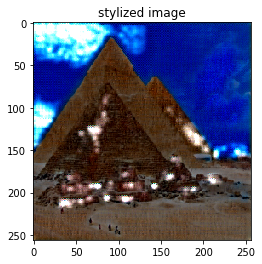

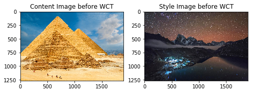

```python
style_transfer_1(content_file_name = './pyramids.jpg', style_file_name = './night.jpg')
```

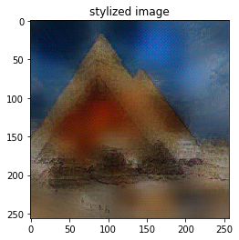

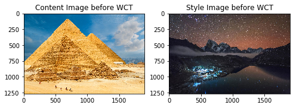

```python
style_transfer_2(content_file_name = './pyramids.jpg', style_file_name = './night.jpg')
```

### Smoothing Contraint

**[10 Points]** Exceptional work: Implement the smoothing constraint from Li et al. to achieve photo realistic style transfer results. Show a few photo style changes from the network. If using code from another author (not your own), you will be graded on the clarity of explanatory comments you add to the code.

We used the smoothing constraint code available at https://github.com/NVIDIA/FastPhotoStyle/blob/master/photo_smooth.py to apply smoothing for photo-realistic image style transfer. The smoothing is intended to remove edge artifacts introduced by the encoding and decoding process.

```python
import scipy.misc
import numpy as np
import scipy.sparse
import scipy.sparse.linalg
from numpy.lib.stride_tricks import as_strided
from PIL import Image

## code was provided by https://github.com/NVIDIA/FastPhotoStyle/blob/master/photo_smooth.py

# we chose to treat this code as a black box.
# We encountered many difficulties with this lab and completed this section on Sunday evening.
class Propagator():
    def __init__(self, beta=0.9999):
        super(Propagator, self).__init__()
        self.beta = beta

    def process(self, initImg, contentImg):

        if type(contentImg) == str:
            content = scipy.misc.imread(contentImg, mode='RGB')
        else:
            content = contentImg.copy()
        # content = scipy.misc.imread(contentImg, mode='RGB')

        if type(initImg) == str:
            B = scipy.misc.imread(initImg, mode='RGB').astype(np.float64) / 255
        else:
            B = scipy.asarray(initImg).astype(np.float64) / 255
            # B = self.
        # B = scipy.misc.imread(initImg, mode='RGB').astype(np.float64)/255
        h1,w1,k = B.shape
        h = h1 - 4
        w = w1 - 4
        B = B[int((h1-h)/2):int((h1-h)/2+h),int((w1-w)/2):int((w1-w)/2+w),:]
        content = scipy.misc.imresize(content,(h,w))
        B = self.__replication_padding(B,2)
        content = self.__replication_padding(content,2)
        content = content.astype(np.float64)/255
        B = np.reshape(B,(h1*w1,k))
        W = self.__compute_laplacian(content)
        W = W.tocsc()
        dd = W.sum(0)
        dd = np.sqrt(np.power(dd,-1))
        dd = dd.A.squeeze()
        D = scipy.sparse.csc_matrix((dd, (np.arange(0,w1*h1), np.arange(0,w1*h1)))) # 0.026
        S = D.dot(W).dot(D)
        A = scipy.sparse.identity(w1*h1) - self.beta*S
        A = A.tocsc()
        solver = scipy.sparse.linalg.factorized(A)
        V = np.zeros((h1*w1,k))
        V[:,0] = solver(B[:,0])
        V[:,1] = solver(B[:,1])
        V[:,2] = solver(B[:,2])
        V = V*(1-self.beta)
        V = V.reshape(h1,w1,k)
        V = V[2:2+h,2:2+w,:]

        img = Image.fromarray(np.uint8(np.clip(V * 255., 0, 255.)))
        return img

    # Returns sparse matting laplacian
    # The implementation of the function is heavily borrowed from
    # https://github.com/MarcoForte/closed-form-matting/blob/master/closed_form_matting.py
    # We thank Marco Forte for sharing his code.
    def __compute_laplacian(self, img, eps=10**(-7), win_rad=1):
            win_size = (win_rad*2+1)**2
            h, w, d = img.shape
            c_h, c_w = h - 2*win_rad, w - 2*win_rad
            win_diam = win_rad*2+1
            indsM = np.arange(h*w).reshape((h, w))
            ravelImg = img.reshape(h*w, d)
            win_inds = self.__rolling_block(indsM, block=(win_diam, win_diam))
            win_inds = win_inds.reshape(c_h, c_w, win_size)
            winI = ravelImg[win_inds]
            win_mu = np.mean(winI, axis=2, keepdims=True)
            win_var = np.einsum('...ji,...jk ->...ik', winI, winI)/win_size - np.einsum('...ji,...jk ->...ik', win_mu, win_mu)
            inv = np.linalg.inv(win_var + (eps/win_size)*np.eye(3))
            X = np.einsum('...ij,...jk->...ik', winI - win_mu, inv)
            vals = (1/win_size)*(1 + np.einsum('...ij,...kj->...ik', X, winI - win_mu))
            nz_indsCol = np.tile(win_inds, win_size).ravel()
            nz_indsRow = np.repeat(win_inds, win_size).ravel()
            nz_indsVal = vals.ravel()
            L = scipy.sparse.coo_matrix((nz_indsVal, (nz_indsRow, nz_indsCol)), shape=(h*w, h*w))
            return L

    def __replication_padding(self, arr,pad):
            h,w,c = arr.shape
            ans = np.zeros((h+pad*2,w+pad*2,c))
            for i in range(c):
                    ans[:,:,i] = np.pad(arr[:,:,i],pad_width=(pad,pad),mode='edge')
            return ans

    def __rolling_block(self, A, block=(3, 3)):
        shape = (A.shape[0] - block[0] + 1, A.shape[1] - block[1] + 1) + block
        strides = (A.strides[0], A.strides[1]) + A.strides
        return as_strided(A, shape=shape, strides=strides)
```

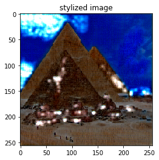

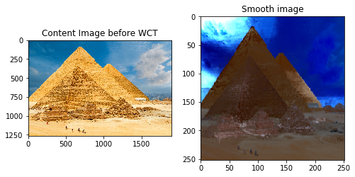

```python
prop = Propagator()
style_transfer_1(content_file_name = './pyramids.jpg', style_file_name = './night.jpg', propagator=prop)
```

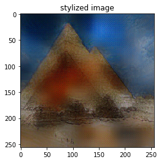

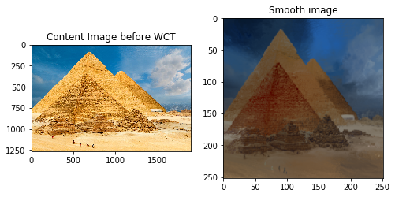

```python
style_transfer_2(content_file_name = './pyramids.jpg', style_file_name = './night.jpg', propagator=prop)
```